# Aside

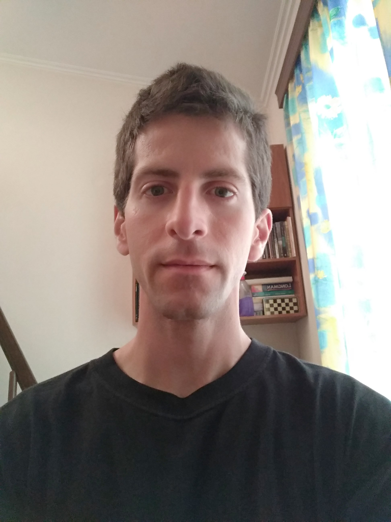

## Contact Info

- bblodfon@gmail.com
- john.zobolas@ntnu.no
- github.com/bblodfon
- [bit.ly/2NpSWLw](https://www.researchgate.net/profile/John_Zobolas)
- [bit.ly/2TaPWbg](https://www.linkedin.com/in/JohnZobolas/)
- bblodfon
- +47 96808973
- +30 6936586236

## Skills

- Highly skilled in R (Rstudio), Java (IntelliJ, mvn), Javascript (WebStorm, npm)
- Highly experienced in Linux, MS office
- Familiar with Python, LaTeX, PHP, SQL, MATLAB, Prolog, C

## Disclaimer

This CV was made with the R package [**pagedown**](https://github.com/rstudio/pagedown).

Last updated on 2019-02-24.

# Main

## Education

### National Technical University of Athens (NTUA)

M.Eng in Electrical and Computer Engineering

Athens, Greece

2007 - 2013

Thesis: Optimal Power Allocation in the uplink of Two-Tier Wireless Femtocell Networks

- Diploma degree: **8.4**

### Athens University of Economics and Business (AUEB)

MSc in Computer Science

Athens, Greece

2013 - 2015

Thesis: SkyLighting Web Application with three.js

- Diploma degree: **9.4**

### Norwegian University of Science and Technology (NTNU)

PhD in Computational Biology

Trondheim, Norway

2017 - 2021 (expected)

I am currently enrolled in the PhD programme in Medical Technology, while being a member of the multidisciplinary DrugLogics group in the department of Clinical and Molecular Medicine (St. Olav’s University Hospital). My areas of interest include:

- Logical modeling of molecular networks and cancer cell systems
- Computer simulations and analysis of synergistic drug combinations
- Mathematical models that describe drug synergy
- Software development mostly in the area of data interoperability and biocuration

## Professional Experience

### Database Performance Testing

Commsquare

Athens, Greece

2013 - 2014

- Testing different DB engines (MyISAM, XtraDB, TokuDB)
- Tuning the OS filesystem (Linux)
- Tuning the server’s database configuration parameters
- Optimizing the table schema, indexes and query performance
- Maximize insertion speed performance

### Linux Systems Engineer

Commsquare

Athens, Greece

2014 - 2015

- Administration/Monitoring of Linux servers & Databases
- Managing Customer Service Software & Support Ticket System
- Installation of Datamon software
- Software testing

## Selected Publications and Posters

### DrugLogics: An ensemble model analysis related to drug prediction performance

[Poster](https://doi.org/10.7490/f1000research.1116420.1) presented at the 55th Norwegian Biochemical Society (NBS) contact meeting

Røros, Norway

2019

**John Zobolas**, Miguel Vazquez, Martin Kuiper, Åsmund Flobak

## Awards and Scholarships

### Program «Great Moment for Education», Eurobank

Award for the highest grade in the Panhellenic examinations

2007

### Program «Study with Scholarship», EqualSociety

Scholarship that paid for the MSc in Computer Science (AUEB)

2013

## Music

### School of Piano and Harmony

Graduated with honours from Anagennisi Conservatory

Athens, Greece

2000 - 2007

### Pianist

Worked as a pianist in Konstantinidis pastry shops

Goudi, Athens

2009 - 2012

### Youtube

I maintain a youtube channel where I upload classical and contemporary piano music, transcriptions from anime, movies and games as well as my own improvisations

2014